# assignment_02_key

## VIF Visual cmparison

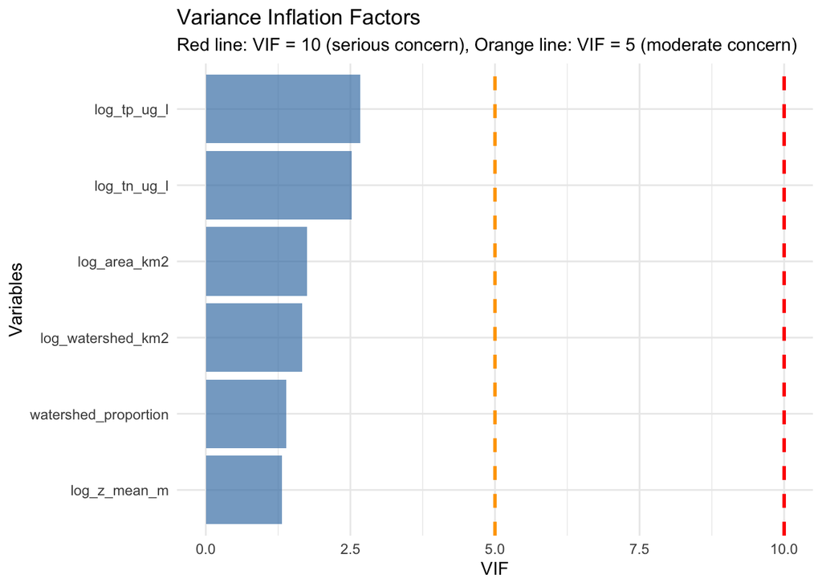

```r
# Create a data frame for better visualization
vif_log_all_df <- data.frame(
  Variable = names(vif_log_all_values),
  VIF = as.numeric(vif_log_all_values)
) %>%
  arrange(desc(VIF))

# Visualize VIF values
ggplot(vif_log_all_df, aes(x = reorder(Variable, VIF), y = VIF)) +
  geom_col(fill = "steelblue", alpha = 0.7) +
  geom_hline(yintercept = 10, color = "red", linetype = "dashed",
             linewidth = 1) +
  geom_hline(yintercept = 5, color = "orange", linetype = "dashed",
             linewidth = 1) +
  coord_flip() +
  labs(
    title = "Variance Inflation Factors",
    subtitle = "Red line: VIF = 10 (serious concern), Orange line: VIF = 5 (moderate concern)",
    x = "Variables",
    y = "VIF"
  ) +
  theme_minimal()
```

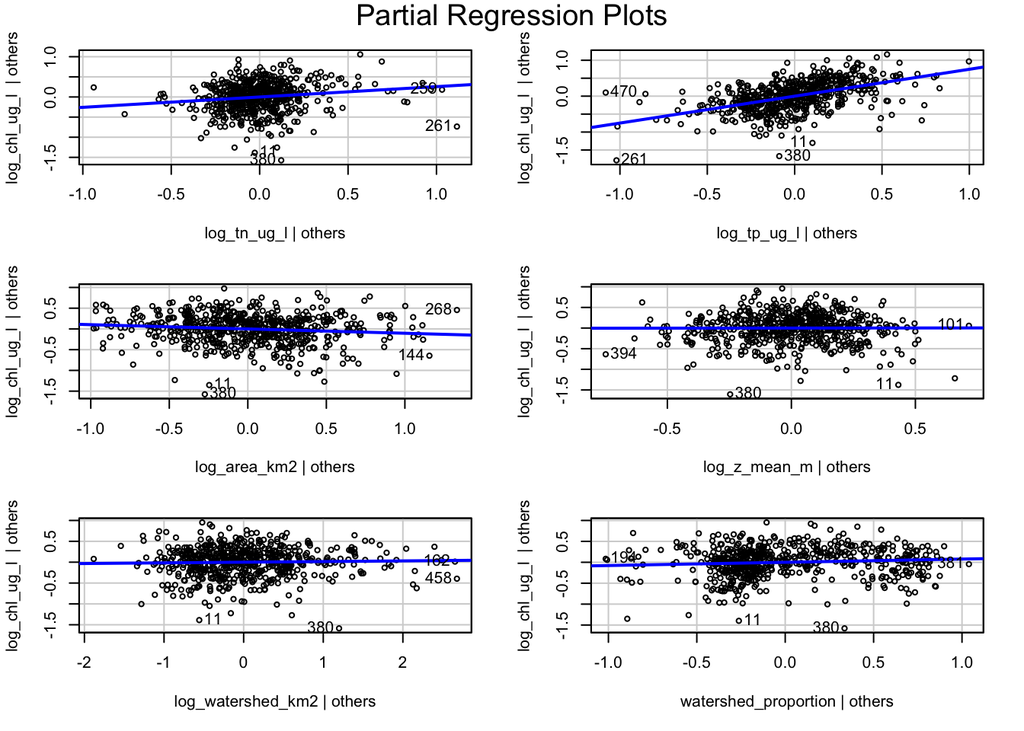

```r
# Create partial regression plots (Added Variable Plots)
# This helps us see the relationship between each predictor and response
# after accounting for other variables

par(mfrow = c(2, 3))
avPlots(model_log_all, main = "Partial Regression Plots")
```

```r
par(mfrow = c(1, 1))
```

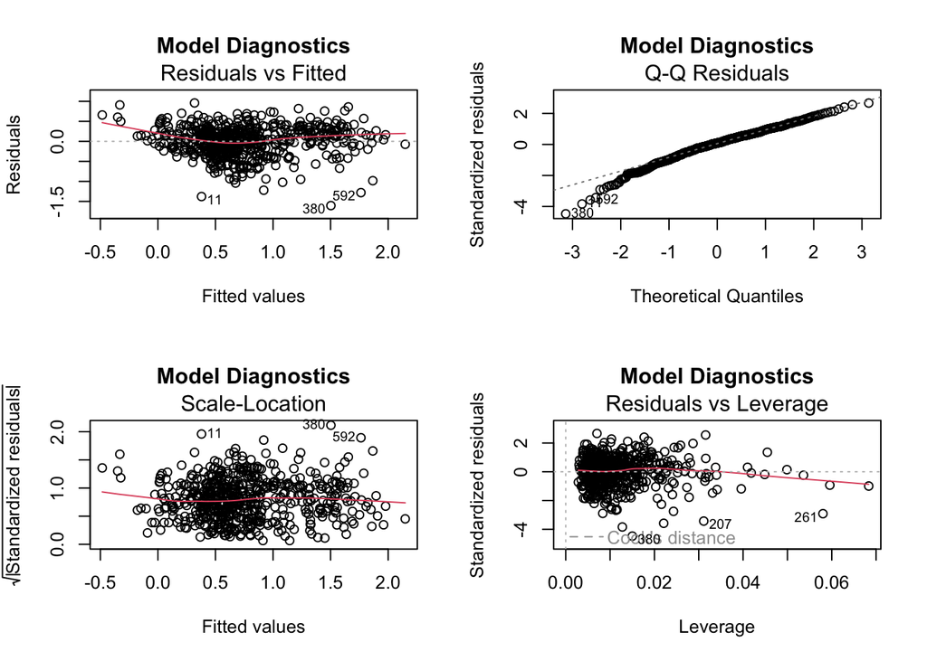

```r
# Create diagnostic plots
par(mfrow = c(2, 2))
plot(model_log_all, main = "Model Diagnostics")
```

```r
par(mfrow = c(1, 1))
```

## Note log of all is ok too but makes it hard to interpret the data…

# compare the AIC of all the models

```r
# Quick diagnostic comparison
cat("Initial response AIC:", round(AIC(model_initial), 2), "\n")
```

```
Initial response AIC: 5299.87
```

```r
cat("Log response AIC:", round(AIC(model_log_response), 2), "\n")
```

```
Log response AIC: 623.49
```

```r
cat("Log all AIC:", round(AIC(model_log_all), 2), "\n")
```

```
Log all AIC: 484.87
```

## AIC is way better for log respinse and a bit better for log all but still messy…

# Model Simplification and Comparison

## Remove Non-significant Variables

So this means removing area_km2 and watershed_km2 and lets see where we are

```r
# # Fit initial model with all predictors (Model 1)
# model_log_response <- lm(log_chl_ug_l ~ tn_ug_l + tp_ug_l + area_km2 +
#                 z_mean_m + watershed_km2 + watershed_proportion , data = lake_df)

# Get model summary
summary(model_log_response)
```

```
Call:
lm(formula = log_chl_ug_l ~ tn_ug_l + tp_ug_l + area_km2 + z_mean_m +
    watershed_km2 + watershed_proportion, data = lake_df)

Residuals:
     Min       1Q   Median       3Q      Max
-1.94887 -0.26553  0.01545  0.29255  1.00743

Coefficients:
                       Estimate Std. Error t value Pr(>|t|)
(Intercept)           5.943e-01  3.754e-02  15.832  < 2e-16 ***
tn_ug_l               7.195e-05  1.373e-05   5.241 2.24e-07 ***
tp_ug_l               3.868e-03  3.118e-04  12.408  < 2e-16 ***
area_km2              2.498e-05  3.015e-05   0.829    0.408
z_mean_m             -3.388e-02  6.493e-03  -5.218 2.51e-07 ***
watershed_km2        -1.901e-05  1.187e-05  -1.602    0.110
watershed_proportion  2.453e-01  3.899e-02   6.291 6.18e-10 ***
---
Signif. codes:  0 '***' 0.001 '**' 0.01 '*' 0.05 '.' 0.1 ' ' 1

Residual standard error: 0.4063 on 586 degrees of freedom
Multiple R-squared:  0.4959,    Adjusted R-squared:  0.4907
F-statistic: 96.07 on 6 and 586 DF,  p-value: < 2.2e-16
```

# Simplified Model

```r
model_log_response_reduced <- lm(log_chl_ug_l ~ tn_ug_l + tp_ug_l +
                z_mean_m + watershed_proportion , data = lake_df)

# Get model summary
summary(model_log_response_reduced)
```

```
Call:
lm(formula = log_chl_ug_l ~ tn_ug_l + tp_ug_l + z_mean_m + watershed_proportion,
    data = lake_df)

Residuals:
     Min       1Q   Median       3Q      Max
-1.94094 -0.26415  0.01817  0.29139  1.01224

Coefficients:
                       Estimate Std. Error t value Pr(>|t|)
(Intercept)           5.876e-01  3.606e-02  16.293  < 2e-16 ***
tn_ug_l               6.661e-05  1.315e-05   5.065 5.46e-07 ***
tp_ug_l               3.883e-03  3.105e-04  12.506  < 2e-16 ***
z_mean_m             -3.156e-02  5.481e-03  -5.758 1.37e-08 ***
watershed_proportion  2.524e-01  3.845e-02   6.565 1.15e-10 ***
---
Signif. codes:  0 '***' 0.001 '**' 0.01 '*' 0.05 '.' 0.1 ' ' 1

Residual standard error: 0.4065 on 588 degrees of freedom
Multiple R-squared:  0.4936,    Adjusted R-squared:  0.4902
F-statistic: 143.3 on 4 and 588 DF,  p-value: < 2.2e-16
```

Ok now we have cool results of how all of these affect the model and the model looks good…

# Get a tidy model

```r
final_summary <- tidy(model_log_response_reduced, conf.int = TRUE)
final_summary
```

```
# A tibble: 5 × 7
  term                  estimate std.error statistic  p.value conf.low conf.high
  <chr>                    <dbl>     <dbl>     <dbl>    <dbl>    <dbl>     <dbl>
1 (Intercept)            5.88e-1 0.0361        16.3  1.57e-49  5.17e-1   6.58e-1
2 tn_ug_l                6.66e-5 0.0000131      5.07 5.46e- 7  4.08e-5   9.24e-5
3 tp_ug_l                3.88e-3 0.000310      12.5  5.51e-32  3.27e-3   4.49e-3
4 z_mean_m              -3.16e-2 0.00548       -5.76 1.37e- 8 -4.23e-2  -2.08e-2
5 watershed_proportion   2.52e-1 0.0384         6.56 1.15e-10  1.77e-1   3.28e-1
```

# Calculate partial R-squared for each variable

```r
anova_table <- anova(model_log_response_reduced)
print("ANOVA Table:")
```

```
[1] "ANOVA Table:"
```

```r
print(anova_table)
```

```
Analysis of Variance Table

Response: log_chl_ug_l
                      Df Sum Sq Mean Sq F value    Pr(>F)
tn_ug_l                1 39.450  39.450 238.784 < 2.2e-16 ***
tp_ug_l                1 42.310  42.310 256.092 < 2.2e-16 ***
z_mean_m               1  5.818   5.818  35.218 5.039e-09 ***
watershed_proportion   1  7.120   7.120  43.094 1.147e-10 ***
Residuals            588 97.145   0.165
---
Signif. codes:  0 '***' 0.001 '**' 0.01 '*' 0.05 '.' 0.1 ' ' 1
```

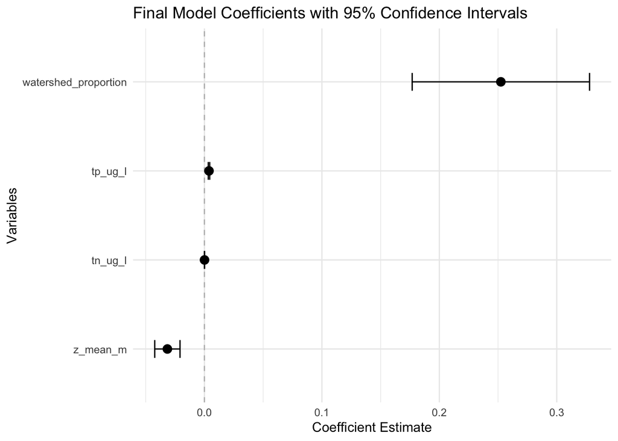

```r
# Create coefficient plot
final_summary %>%
  filter(term != "(Intercept)") %>%
  mutate(term = fct_reorder(term, estimate)) %>%
  ggplot(aes(x = estimate, y = term)) +
  geom_vline(xintercept = 0, linetype = "dashed", color = "gray") +
  geom_point(size = 3) +
  geom_errorbarh(aes(xmin = conf.low, xmax = conf.high), height = 0.2) +
  labs(
    title = "Final Model Coefficients with 95% Confidence Intervals",
    x = "Coefficient Estimate",
    y = "Variables"
  ) +
  theme_minimal()
```

Interpreting Each Coefficient: 1. Total Nitrogen (tn_ug_l = 6.661e-05)

Meaning: For every 1 μg/L increase in TN, log₁₀(Chl-a) increases by 0.0000666 units Practical interpretation:

A 100 μg/L increase in TN → 0.00666 increase in log₁₀(Chl-a) This equals 10^0.00666 = 1.015-fold change (1.5% increase in Chl-a)

Or more meaningfully: A 1000 μg/L increase in TN → 15% increase in Chl-a

2. Total Phosphorus (tp_ug_l = 3.883e-03)

Meaning: For every 1 μg/L increase in TP, log₁₀(Chl-a) increases by 0.00388 units Practical interpretation:

A 10 μg/L increase in TP → 0.0388 increase in log₁₀(Chl-a) This equals 10^0.0388 = 1.094-fold change (9.4% increase in Chl-a)

Strong effect: TP has much stronger per-unit effect than TN

3. Mean Depth (z_mean_m = -3.156e-02)

Meaning: For every 1 meter increase in depth, log₁₀(Chl-a) decreases by 0.0316 units Practical interpretation:

A 5-meter deeper lake → 0.158 decrease in log₁₀(Chl-a) This equals 10^-0.158 = 0.695-fold change (30% decrease in Chl-a)

Clear ecological meaning: Deeper lakes have less algae (light limitation)

4. Watershed Land Use (watershed_proportion = 2.524e-01)

Meaning: Lakes with high ag/urban watersheds have 0.252 higher log₁₀(Chl-a) Practical interpretation:

High ag/urban watersheds → 10^0.252 = 1.79-fold higher Chl-a 79% more algae in agricultural/urban watersheds vs. natural watersheds

Model Performance:

R² = 0.494: Model explains 49% of variation in log(Chl-a) All predictors significant (p < 0.001) F-statistic highly significant: Overall model is valid

Ranking Effect Sizes:

Watershed land use: Strongest effect (79% difference) Lake depth: Moderate-strong effect (30% per 5m) Total phosphorus: Moderate effect per unit, but nutrients vary widely Total nitrogen: Weakest per-unit effect

Ecological Interpretation: This model shows that chlorophyll-a concentrations are primarily driven by:

Nutrient inputs (especially phosphorus) Light availability (deeper lakes = less algae) Watershed disturbance (agriculture/urban = more nutrients/algae)

The untransformed predictors make this easier to interpret in original units that managers understand!

A great write up